# Happy To Be “Me?” Authenticity, Psychological Need Satisfaction, and Subjective Well‐Being in Adolescence - Thomaes - 2017 - Child Development - Wiley Online Library

[Child Development](https://srcd.onlinelibrary.wiley.com/journal/14678624)

[Volume 88, Issue 4](https://srcd.onlinelibrary.wiley.com/toc/14678624/2017/88/4) p. 1045-1056

[figure not shown]

Special Section

Full Access

# Happy To Be “Me?” Authenticity, Psychological Need Satisfaction, and Subjective Well-Being in Adolescence

[Sander Thomaes](https://srcd.onlinelibrary.wiley.com/action/doSearch?ContribAuthorRaw=Thomaes%2C+Sander),

Correspondence concerning this article should be addressed to Sander Thomaes, Utrecht University, 80140 3508 TC Utrecht, The Netherlands. Electronic mail may be sent to .

[Constantine Sedikides](https://srcd.onlinelibrary.wiley.com/action/doSearch?ContribAuthorRaw=Sedikides%2C+Constantine),

[Nellie van den Bos](https://srcd.onlinelibrary.wiley.com/action/doSearch?ContribAuthorRaw=Bos%2C+Nellie),

[Roos Hutteman](https://srcd.onlinelibrary.wiley.com/action/doSearch?ContribAuthorRaw=Hutteman%2C+Roos),

[Albert Reijntjes](https://srcd.onlinelibrary.wiley.com/action/doSearch?ContribAuthorRaw=Reijntjes%2C+Albert),

First published: 09 June 2017

https://doi.org/10.1111/cdev.12867

Citations: 53

## Abstract

Adolescents have a strong desire to “be themselves.” How does experiencing authenticity—the sense of being one's true self—influence subjective well-being? What allows adolescents to experience authenticity? This research tests a working model of how authenticity is implicated in adolescents’ well-being. Using survey, diary, and experimental methodologies, four studies (total *N* = 759, age range = 12–17) supported the main tenets of the model. Authenticity (a) enhances well-being, (b) covaries with satisfaction of psychological needs for relatedness and competence; is caused by satisfaction of the need for autonomy; and (c) mediates the link between need satisfaction and well-being. Authenticity is more than a powerful motive: It has robust, replicable effects on well-being and may thus be a pervasive force in positive youth development.

“Who is the real me? Am I my true self? Do I act like the person I really am?” Adolescence is a time when the search for authenticity—the sense of being one's true self—is of paramount concern: Many adolescents think they will fare best, if they succeed at “putting off their masks” and “being themselves” (Harter, 2002, 2012; Ullman, 1987). Philosophers (e.g., existentialists such as Heidegger, Kierkegaard, and Sartre; Macquarrie, 1972) and psychologists (e.g., Harter, 2012; Rogers, 1961; Winnicott, 1965) concur, as they have regarded authenticity fundamental to human growth and healthy psychological development. Yet, with few exceptions (Harter, Marold, Whitesell, & Cobbs, 1996; Impett, Sorsoli, Schooler, Henson, & Tolman, 2008; Theran, 2011), authenticity and its involvement in positive youth development has been largely neglected in empirical adolescent psychology. Does authenticity influence adolescents’ subjective well-being, as is often assumed? If so, what social and psychological factors allow adolescents to experience authenticity in the first place?

Building on self-determination theory (SDT; Deci & Ryan, 2000; Ryan & Deci, 2000), the present research posits and tests a working model of how authenticity is implicated in adolescents’ subjective well-being (Figure 1). The model proposes that, whether operationalized as a trait or state, authenticity (a) stems from satisfaction of basic psychological needs for autonomy (experiencing volition in one's actions), relatedness (experiencing closeness with significant others), and competence (experiencing self-efficacy); (b) enhances subjective well-being, conceptualized as high levels of positive emotional experience and low levels of negative emotional experience; and in fact, (c) drives the well-established link between psychological need satisfaction and subjective well-being (Deci & Ryan, 2000; Niemiec & Ryan, 2009; Ryan & Deci, 2000). Put differently, adolescents feel more true to themselves when their basic psychological needs are met, and it is this sense of authenticity that contributes to their higher subjective well-being.

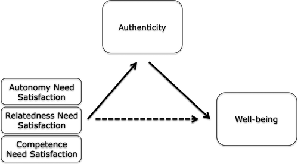

**Figure 1**

Working model showing the relation between psychological need satisfaction and subjective well-being, mediated by authenticity.

### Psychological Need Satisfaction and Subjective Well-Being

SDT constitutes a useful framework for understanding positive youth development. The theory offers an organismic perspective on human development, as it assumes that individuals have a natural tendency for psychological growth and adjustment. Specifically, SDT posits that human development is organized by innate, adaptive processes that predispose youth to be active and inquisitive, and to experience integrity and well-being. The theory does not explain problematic or stalled development in terms of inherent individual deficiencies or risks but rather as driven by contextual factors. SDT holds that human beings have three basic psychological needs—for autonomy, relatedness, and competence—which, throughout development, are satisfied or thwarted in ongoing interaction with their social world. The degree of need satisfaction, in turn, is considered vital for psychological growth and well-being (Deci & Ryan, 2000; Ryan & Deci, 2000). Thus, SDT informs developmental theory by specifying the contextual factors that nurture youths’ inner potential for healthy development.

Importantly, autonomy and authenticity are partially overlapping but distinct concepts. Autonomy refers to the degree to which individuals experience choicefulness in their actions (vs. pressure by external factors; Soenens & Vansteenkiste, 2005), whereas authenticity refers to the degree to which individuals feel that they as a person are true or real (vs. fake or phony; Harter, 2012).

There is considerable empirical evidence for the proposition that psychological need satisfaction fosters adolescents’ subjective well-being (for similar evidence involving adults, see Reis, Sheldon, Gable, Roscoe, & Ryan, 2000; Sheldon & Elliot, 1999). Between-person differences in basic psychological need satisfaction are associated with multiple indicators of subjective well-being, including positive affect, vitality, school engagement, and life satisfaction—as found in cross-sectional (Leversen, Danielsen, Birkeland, & Samdal, 2012), longitudinal (Tian, Chen, & Huebner, 2014; Véronneau, Koestner, & Abela, 2005), and experimental (Savard, Joussemet, Emond Pelletier, & Mageau, 2013; Simões & Alarcão, 2014) research. Similarly, within-person differences (i.e., temporary, intraindividual fluctuations) in basic psychological need satisfaction covary reliably with subjective well-being (Mouratidis, Vansteenkiste, Sideridis, & Lens, 2011).

### Authenticity as Mediator?

Less is known about *how* basic psychological need satisfaction enhances adolescents’ subjective well-being. We propose that authenticity plays an important role in this process. According to SDT, when individuals feel that their psychological needs are met, they will be more likely to accept and freely express their internal states (values, emotions, and desires). Thus, from this perspective, psychological need satisfaction should facilitate authenticity (Kernis & Goldman, 2006). Conversely, when individuals’ psychological needs are insufficiently met, they might experience a stronger incentive to alienate their internal states. They might adopt modes of behavior that are exhibited for extrinsic purposes, such as to please others (e.g., to gain a sense of relatedness), to appear self-reliant (e.g., to gain a sense of autonomy), or to win others’ or one's own esteem (e.g., to gain a sense of competence; Goldman & Kernis, 2002; Harter et al., 1996; Impett et al., 2008).

There is some circumstantial evidence for the presumed link between need satisfaction and adolescents’ authenticity. For example, cross-sectional research has shown that, when adolescents experience positive relatedness and autonomy support in their relationships with parents, they show more self-determined behavior (i.e., they are more likely to enact self-endorsed behaviors based on their personal beliefs—a behavioral expression of authenticity; Soenens & Vansteenkiste, 2005; Soenens et al., 2007) and show less false self-behavior (i.e., they are less likely to enact behaviors discrepant with what they perceive to be their true self—a behavioral expression of inauthenticity; Harter et al., 1996). However, evidence for temporal precedence or causality of the link between need satisfaction and authenticity is lacking.

The second part of our proposed causal chain, the link between authenticity and subjective well-being, is equally understudied in adolescents. Psychological theory (Harter, 2012; Winnicott, 1965) has emphasized authenticity as a key determinant of subjective well-being. The assumption is that authenticity, and its associated subjective experience of integrity and coherence of the self, will increase individuals’ satisfaction with themselves, facilitate positive emotions, and help reduce negative emotions. Indeed, survey and experimental findings involving adults have indicated that authenticity is associated with and increases positive affect and life satisfaction, and simultaneously is inversely associated with and decreases negative affect and self-consciousness (Kifer, Heller, Perunovic, & Galinsky, 2013; Lenton, Slabu, Sedikides, & Power, 2013; Wood, Linley, Maltby, Baliousis, & Joseph, 2008). However, evidence from research involving adolescents is lacking, which is surprising given the presumed ubiquity of the authenticity motive in adolescence.

### Overview

We use survey methods (Study 1), daily diary methods (Study 2), and experimental methods (Studies 3 and 4) to test the overall hypothesis that psychological need satisfaction fosters subjective well-being by raising authenticity among adolescents. We assess individuals’ self-perceived level of authenticity, both as a trait (Study 1) and as a state (Studies 2–4). This way, we do right to evidence that authenticity has both trait and state components (Lenton, Bruder, Slabu, & Sedikides, 2013): Trait authenticity refers to a person's general inclination toward authenticity as a stable attribute (Wood et al., 2008), whereas state authenticity refers to a person's authenticity in a particular situation or relatively short time frame. Trait authenticity also differs from state authenticity in that it requires inference rather than direct experience to be discerned (Lenton, Bruder, et al., 2013). Our studies focus primarily on the experiential component of authenticity: the degree to which one feels, or perceives oneself to be, coherent and “real” (Fleeson & Wilt, 2010; Lenton, Bruder, et al., 2013). Participants were 12–17 years old. We studied adolescents because of the significance they attach to being authentic (Harter, 2012; Ullman, 1987), which may render authenticity particularly consequential at this age.

## Study 1

In Study 1, we used survey methods to evaluate the hypothesis that dispositional levels of psychological need satisfaction and subjective well-being are positively associated, and that trait authenticity mediates this link. We tested the robustness of authenticity's putative mediational role by assessing it both via a questionnaire and pictorially.

### Method

#### Participants

Participants were 155 adolescents (52% female; *M*<sub>age</sub> = 13.9, *SD*<sub>age</sub> = 1.3; 91% native English) recruited from two secondary schools serving middle-class communities in southern England. Participants received parental consent (parental consent rate = 75%) and provided their own assent (participant assent rate = 92%).

#### Procedure

Study 1 was conducted in spring 2014. Participants completed a survey in their regular classrooms. We assessed *psychological need satisfaction* with the 21-item Basic Psychological Needs Scale (Gagné, 2003). This scale measures the degree to which participants experience the needs for autonomy (e.g., *I generally feel free to express my ideas and opinions*; *In my daily life, I frequently have to do what I am told* [reverse scored]), relatedness (e.g., *People in my life care about me*; *I really like the people I interact with*), and competence (e.g., *Most days I feel a sense of accomplishment from what I do*; *Often I do not feel very competent* [reverse scored]) to be satisfied in their lives. Responses ranged from 1 (*strongly disagree*) to 7 (*strongly agree*). Descriptive statistics were as follows: for autonomy, *M* = 4.45, *SD* = 0.99, α = .65; for relatedness, *M* = 5.44, *SD* = 0.87, α = .80; for competence, *M* = 4.67, *SD* = 1.02, α = .75.

We assessed *authenticity* with the 12-item Authenticity Scale (Wood et al., 2008). This scale measures authenticity in terms of the degree to which individuals perceive themselves as being in touch with and acting on their true selves, and as being relatively immune to others’ views and influences (e.g., *I am true to myself in most situations; I feel out of touch with the real me* [reverse scored]). Responses ranged from 1 (*does not describe me at all*) to 5 (*describes me very well*; *M* = 3.50, *SD* = 0.52, α = .70). As an additional measure of authenticity, we administered the Real-Self Overlap Scale (RSOS; Lenton, Bruder, et al., 2013). This single-item pictorial scale assesses the degree to which participants feel close to their true or “real” self. The RSOS depicts seven pairs of circles, varying in degree of overlap between them, with one circle representing “real me” and the other “me generally.” Participants selected the pair of circles that best represents how close they generally feel to their real self, ranging from 1 (*nonoverlapping circles*) to 7 (*strongly overlapping circles*; *M* = 3.64, *SD* = 1.72). The Authenticity Scale and RSOS were correlated (*r* = .38, *p* < .001).

Finally, we assessed *subjective well-being* with three scales measuring dispositional positive and negative affects, and life satisfaction. The 10-item positive (e.g., *excited*, *interested*) and negative (e.g., *distressed*, *jittery*) affect scales of the Positive and Negative Affect Schedule (PANAS; Watson, Clark, & Tellegen, 1988) measure the extent to which participants “generally experience” positive and negative feelings. Responses ranged from 1 (*very slightly or not at all*) to 5 (*extremely*): for positive affect, *M* = 3.19, *SD* = 0.74, α = .84; for negative affect, *M* = 2.21, *SD* = 0.82, α = .83. The five-item Satisfaction With Life Scale (SWLS; Diener, Emmons, Larsen, & Griffin, 1985; e.g., *I am satisfied with my life*) measures the degree to which participants value the quality of their lives. Responses ranged from 1 (*strongly disagree*) to 7 (*strongly agree*; *M* = 4.78, *SD* = 1.32, α = .85). The correlations between the three indicators of subjective well-being ranged from *r* = |.38| to .66, *p*s < .001. Following standard procedures (Kifer et al., 2013), we computed subjective well-being by summing the standardized life satisfaction and positive affect scales and subtracting the standardized negative affect scale (*M* = 0.00, *SD* = 2.45).

### Results and Discussion

Across authenticity measures, and for each of the psychological needs, the predictions were supported. Regression analyses showed that basic psychological need satisfaction was significantly associated with subjective well-being (for autonomy: *t* = 8.01, *b* = 1.40, *p* < .001; for relatedness: *t* = 7.50, *b* = 1.40, *p* < .001; and for competence: *t* = 11.31, *b* = 1.64, *p* < .001). Furthermore, basic psychological need satisfaction was significantly associated with authenticity as measured using the questionnaire (for autonomy: *t* = 6.98, *b* = 0.26, *p* < .001; for relatedness: *t* = 3.84, *b* = 0.18, *p* < .001; and for competence: *t* = 6.10, *b* = 0.22, *p* < .001) and using the pictorial measure (for autonomy: *t* = 5.51, *b* = 0.71, *p* < .001; for relatedness: *t* = 4.79, *b* = 0.64, *p* < .001; and for competence: *t* = 5.74, *b* = 0.73, *p* < .001). Also, authenticity was significantly associated with subjective well-being (using the questionnaire: *t* = 5.87, *b* = 0.83, *p* < .001; and using the pictorial measure: *t* = 5.66, *b* = 0.60, *p* < .001).

Bootstrapping mediation tests (Preacher & Hayes, 2008), based on 5,000 bootstrap samples, showed that trait authenticity significantly mediated the link between basic psychological need satisfaction and subjective well-being. In these tests, mediation is indicated when the 95% bias-corrected confidence interval for the indirect effect (i.e., the effect of need satisfaction on well-being via authenticity) does not include zero. This was the case for each of the three models involving need satisfaction of autonomy, relatedness, and competence; and for both measures of authenticity. Table 1 presents the direct and indirect effects and confidence intervals. Thus, Study 1 suggests that individual differences in trait authenticity account for the well-established link between basic psychological need satisfaction and adolescents’ subjective well-being.

Table 1. Results of Mediation Analyses Testing Whether the Link Between Basic Psychological Need Satisfaction and Subjective Well-Being Is Mediated by Authenticity (Studies 1, 2, and 3)

| Study | Direct effect | Indirect effect | 95% CI |
| --- | --- | --- | --- |
| Study 1: Need satisfaction (relatedness) → authenticity → well-being | 1.40* | .24* | [.11, .44] |
| Study 1: Need satisfaction (autonomy) → authenticity → well-being | 1.40* | .18* | [.03, .40] |
| Study 1: need satisfaction (competence) → authenticity → well-being | 1.64* | .14* | [.01, .30] |
| Study 1: Need satisfaction (relatedness) → actual/true self overlap → well-being | 1.44* | .25* | [.07, .49] |
| Study 1: Need satisfaction (autonomy) → actual/true self overlap → well-being | 1.40* | .19* | [.04, .43] |
| Study 1: Need satisfaction (competence) → actual/true self overlap → well-being | 1.64* | .13* | [.01, .32] |
| Study 2: Daily need satisfaction (relatedness) → daily authenticity → daily well-being | 0.30*** | .16* | [.13, .20] |
| Study 2: Daily need satisfaction (autonomy) → daily authenticity → daily well-being | 0.18*** | .13* | [.10, .16] |
| Study 2: Daily need satisfaction (competence) → daily authenticity → daily well-being | 0.28*** | .14* | [.11, .18] |
| Study 3: Experimentally induced need satisfaction (autonomy) → state authenticity → state well-being | −0.02 | .30* | [.11, .49] |

### Note

- Bootstrap analyses are based on 5,000 bootstrap samples. Unstandardized regression coefficients are reported. Mediation is interpreted as significant when confidence interval for indirect effect does not include zero.
- **p* < .05. ****p* < .001.

## Study 2

Study 2 builds on Study 1 by exploring relations between need satisfaction, authenticity, and subjective well-being in a naturalistic setting via a daily diary. We tested the hypothesized model in terms of within-person psychological states rather than between-person psychological traits. We evaluated the hypothesis that state authenticity mediates the putative covariation of daily levels of need satisfaction and subjective well-being.

### Method

#### Participants

Participants were 172 adolescents (67% female; *M*<sub>age</sub> = 14.8, *SD*<sub>age</sub> = 1.1; 95% native Dutch) recruited from two secondary schools serving middle-class communities in the Netherlands. Participants received parental consent (parental consent rate = 99%) and gave their own assent (participant assent rate = 100%). They received gift vouchers worth about $20 for their participation.

#### Procedure

Study 2 was conducted in autumn 2014. Participants completed a brief (< 5-min) online survey at the end of the day for 10 consecutive weekdays (i.e., two school weeks). The survey included a total of 17 items to measure daily levels of psychological need satisfaction, authenticity, and subjective well-being. All items were rated along a 6-point scale (1 = *not true at all*, 6 = *very true*). We assessed *daily need satisfaction* with two items measuring core manifestations of each need. Examples are: for autonomy, *Today I could do things I find interesting or important*; for relatedness, *Today I got along with the people I interacted with*; and for competence, *Today I was competent in the things I did*. Descriptive statistics were as follows for autonomy satisfaction, relatedness satisfaction, and competence satisfaction, respectively: range in daily means was 2.97–3.84, 3.74–4.13, and 3.49–3.98; range in daily standard deviations was 0.99–1.24, 0.79–1.10, and 0.92–1.19; range in daily correlations between the two relevant items was .47–.90, .41–.69, and .66–.89.

We assessed *daily authenticity* with three items (*Today I was my true self*, *Today I acted as I really am*, *Today I was “real” and authentic*; range in daily means was 3.79–4.15; range in daily standard deviations was 0.74–1.00; range in daily alphas was .86–.95). We assessed *daily subjective well-being*, indexed here by positive and negative affects, with four positive affect items (*[Today I felt] happy, excited, relaxed, satisfied*) and four negative affect items (*[Today I felt] angry, anxious, depressed, sad*; Kuppens, Allen, & Sheeber, 2010). We computed a measure of subjective well-being by reverse coding negative affect items and averaging responses (range in daily means was 3.46–4.16; range in daily standard deviations was 0.75–1.34; range in daily alphas was .88–.93).

### Results and Discussion

The data constituted a multilevel structure with occasions (days) nested within individuals. We conducted the analyses by means of two-level structural equation modeling with the robust maximum likelihood estimator using Mplus version 7.3 (Muthén & Muthén, 1998–2012). To estimate the within-person mediation model, we regressed daily well-being onto daily psychological need satisfaction, and calculated the indirect effect via daily authenticity. We tested mediation separately for each of the three basic needs. Given that bootstrapping is not possible using multilevel analysis in Mplus (Muthén & Muthén, 1998–2012), we bootstrapped model estimations from Mplus (based on 5,000 bootstrap samples) using the MplusAutomation package (Hallquist & Wiley, 2013) in R (R Core Team, 2013).

As hypothesized, day-to-day fluctuations in need satisfaction covaried within persons with fluctuations in both well-being and authenticity. Need satisfaction significantly predicted well-being (for autonomy: *t* = 5.96, *b* = 0.18, *p* < .001; for relatedness: *t* = 6.37, *b* = 0.30, *p* < .001; for competence: *t* = 6.81, *b* = 0.28, *p* < .001). Furthermore, need satisfaction significantly predicted authenticity (for autonomy: *t* = 9.01, *b* = 0.31, *p* < .001; for relatedness: *t* = 10.81, *b* = 0.44, *p* < .001; for competence: *t* = 10.77, *b* = 0.38, *p* < .001). Authenticity, in turn, significantly predicted well-being (*t* = 11.72, *b* = 0.37, *p* < .001).

More important, the hypothesized mediational effect of daily authenticity driving the link between daily experiences of need satisfaction and well-being was supported. Bootstrapping mediation tests revealed that for none of the indirect effects (i.e., involving the three forms of need satisfaction) did the 95% bias-corrected confidence intervals include zero (Table 1).

In all, Study 2 provided further evidence for the hypothesized mediational model in the naturalistic context of adolescents’ daily life, and by examining authenticity as a within-person state (rather than a between-person trait). As adolescents’ need satisfaction rises or falls from day to day, their subjective well-being rises or falls accordingly, and this link is accounted for by authenticity.

Next, we carried out two experiments to evaluate the causal relations implied in our mediational model. Study 3 manipulated psychological need satisfaction, tested its causal effects on state authenticity, and examined whether state authenticity mediates the presumed link between need satisfaction and subjective well-being. Study 4 evaluated the second part of the causal chain: It directly manipulated authenticity and tested its causal impact on subjective well-being.

## Study 3

Study 3 used a four-level between-subjects design. We randomly assigned adolescents to one of three (i.e., autonomy, relatedness, competence) need satisfaction conditions or a neutral control condition. We hypothesized that adolescents in each of the need satisfaction conditions would report higher levels of state authenticity than those in the control condition. We also hypothesized that state authenticity would mediate the presumed link between need satisfaction and subjective well-being.

### Method

#### Participants

Participants were 247 adolescents (56% male; *M*<sub>age</sub> = 15.3, *SD*<sub>age</sub> = 1.0; 98% native Dutch). They were recruited from the youth subject panel of a Dutch online survey company (NovioData, Nijmegen, The Netherlands). Members of the panel are from all regions in the Netherlands and are representative in terms of their level of education. Native Dutch panel members are somewhat overrepresented in comparison to the general population. All participants had parental consent and submitted their own assent. Furthermore, they earned credit to be exchanged for gift vouchers of their choice.

### Results and Discussion

An analysis of variance showed that, as hypothesized, adolescents’ state authenticity differed as a function of condition, *F* = 3.43, *p* < .02, partial η<sup>2</sup> = .04. Planned contrasts revealed that participants in the autonomy satisfaction condition reported significantly higher state authenticity (*M* = 4.67, *SD* = 0.74) than those in the neutral control condition (*M* = 4.22, *SD* = 0.85), *F* = 9.44, *p* < .01, partial η<sup>2</sup> = .07. However, participants in the relatedness satisfaction (*M* = 4.42, *SD* = 0.79) and competence satisfaction (*M* = 4.29, *SD* = 0.86) conditions did not report significantly higher state authenticity than those in the control condition, *p*s > .16. Thus, the causal effect of need satisfaction on state authenticity occurred, specifically, for autonomy need satisfaction.

We proceeded with a mediational analysis and established that participants in the autonomy need satisfaction condition also reported higher levels of subjective well-being (*M* = 4.61, *SD* = 0.56) than did participants in the control condition (*M* = 4.34, *SD* = 0.69), *F* = 5.41, *p* < .03, partial η<sup>2</sup> = .04. Furthermore, state authenticity was positively associated with subjective well-being, *t* = 16.53, *b* = 0.65, *p* < .001. Most important, state authenticity mediated the effect of the autonomy need satisfaction manipulation on state subjective well-being. The bootstrapping mediation test (5,000 bootstrap samples) revealed that the 95% bias-corrected confidence intervals for the indirect effect did not include zero (Table 1).

## Study 4

Study 4, a two-level between-subjects experiment, evaluated the second part of the causal model. Specifically, we manipulated authenticity and tested its effect on subjective well-being. We assigned adolescents to authenticity or control conditions. We assessed subjective well-being again in terms of positive and negative affects. Moreover, as an additional indicator of subjective well-being, we included a measure of subjective vitality, which refers to feeling alive and energetic (Ryan & Frederick, 1997). Subjective vitality is a phenomenologically central aspect of well-being, and is assessed frequently in SDT research (Nix, Ryan, Manly, & Deci, 1999; Ryan & Frederick, 1997). We hypothesized that adolescents in the authenticity condition would report higher levels of subjective well-being.

### Method

#### Participants

Participants were 185 adolescents (58% female; *M*<sub>age</sub> = 15.3, *SD*<sub>age</sub> = 1.5; 94% native Dutch) recruited from two secondary schools serving middle- and upper-class communities in the Netherlands. Participants received parental consent (parental consent rate = 53%), and provided their own assent (participant assent rate = 99%).

#### Procedure

Study 4 was conducted in spring and summer 2015. Participants completed the experiment in their regular classrooms. They worked on the assignments independently and returned their work in an envelope after they finished. They were guided through the experimental procedures via written and self-explanatory instructions. Following standard procedures (Kifer et al., 2013), participants were randomized within their classes to recall and write about “a particular incident in which you could [not] be true to yourself, and in which you experienced yourself as [not] behaving in accord with how you really are inside.” Next, the instructions asked participants to relive the event in their imagination and to write a short essay about what exactly happened in the event and how it made them feel. Participants also reported when the event had happened (*M*<sub>days prior to experiment</sub> = 247, *SD* = 280). This procedure took 5–10 min to complete. Next, participants rated their positive and negative affect “right now” using the state version of the PANAS (1 = *very slightly or not at all*, 5 = *extremely*; for positive affect: *M* = 3.29, *SD* = 0.69, α = .81; for negative affect: *M* = 1.47, *SD* = 0.44, α = .80). They also rated their subjective vitality “right now” using the seven-item Subjective Vitality Scale (Ryan & Frederick, 1997; e.g., *I have energy and spirit*; 1 = *absolutely untrue*, 5 = *absolutely true*; *M* = 3.47, *SD* = 0.90; α = .69). The correlations between the three indicators of subjective well-being ranged from *r* = |.34| to .76, *p*s < .001. Similarly to Study 1, we computed a subjective well-being aggregate by summing the standardized positive affect and subjective vitality scales and subtracting the standardized negative affect scale (*M* = 0.04, *SD* = 2.42).

As a fidelity check of the manipulation, four graduate students read participants’ writings and independently coded how well they had adhered to the instructions (0 = *not good* to 2 = *good*). Fidelity was considered adequate when at least three of the four coders judged instruction adherence to be “good” and none judged instruction adherence to be “not good.” The writings of 15 (8%) participants did not meet fidelity criteria. We excluded these adolescents from the analyses, yielding a final sample of *N* = 170. Excluded participants did not differ from included ones on any of the study variables.

### Results and Discussion

Across conditions, participants who recalled events that happened longer ago reported more positive affect and vitality (*r*s > .18, *p*s < .02; a finding that may reflect the global cognitive focus that tends to co-occur with experiencing positive affect; Fredrickson, 2001). Accordingly, we entered timing of recalled event as a control variable in the analyses. An analysis of covariance showed that the hypothesized causal effect of authenticity on subjective well-being was significant (*F* = 6.40, *p* < .02, partial η<sup>2</sup> = .04): Participants reported experiencing more subjective well-being in the authenticity condition (*M* = 0.30, *SD* = 2.23) than in the control condition (*M* = −0.30, *SD* = 2.61). Thus, Study 4 supports the hypothesis that authenticity has a causal effect on adolescents’ subjective well-being.

## General Discussion

For many adolescents, the desire to be authentic is palpable and strong. They wish to be true to their values, emotions, and desires; at the same time, they often agonize about not being able to be “natural” in their social interactions or worry that they possess conflicting attributes and are therefore not real (Harter, 2002; Ullman, 1987). What social and psychological factors influence the degree to which adolescents experience authenticity? What are the consequences of experiencing authenticity in terms of subjective well-being? In four studies, we obtained evidence that authenticity (a) enhances adolescents’ subjective well-being; (b) covaries with the degree to which basic psychological needs for relatedness and competence are satisfied, while being caused by satisfaction of the need for autonomy; and (c) mediates the link between need satisfaction and subjective well-being.

Our findings contribute to the literature on social and psychological drivers of positive youth development (Benson, Scales, Hamilton, & Semsa, 2006; Lerner, Almerigi, Theokas, & Lerner, 2005; Lerner, Phelps, Forman, & Bowers, 2009) and particularly to its key component of subjective well-being (Park, 2004). When youth fail to contact or enact their internal states, this is often because they think that doing so might lead to rejection or disapproval (Harter et al., 1996; Impett et al., 2008). However, when youths’ basic psychological needs are met, this reduces their incentive to distance themselves from “who they really are” and helps them to experience authenticity. It is this sense of authenticity that, in turn, buoys youth with a stock of positive feelings and promotes subjective well-being.

Several developmental factors may constrain the degree to which adolescents are able to experience authenticity. Adolescence is a time of increasing role differentiation—socialization pressures and social-cognitive maturation influence adolescents progressively to adopt different roles, or social identities, in varied social contexts (e.g., with parents, close friends, romantic partner, or peers; Chen, Boucher, & Tapias, 2006; Harter, Bresnick, Bouchey, & Whitesell, 1997). Ironically, this development toward progressively higher role differentiation occurs at a time when many adolescents, spurred by their increasing ability for self-reflection and introspection, begin to search for a unified sense of who one is and for the characteristics that define one's true self (Harter, 2012). Although these joint developments are natural, they can escalate adolescents’ concern with lack of a coherent, genuine self. Developmental surges in the desire to be approved by peers, and the concomitant subjective pressure to adopt personas that might deviate from one's true self, may further fuel this concern. Yet, as our research indicates, even in the face of these developmental constraints, most adolescents succeed in experiencing moderate to high levels of authenticity at least some of the time. This subjective sense of authenticity is emotionally consequential, as it directly benefits adolescents’ subjective well-being.

Some of our results were unexpected. Although in Studies 1 and 2 we found that satisfaction of each of the three basic needs is strongly associated with authenticity, in Study 3 we found that *causal* effects on authenticity are limited to satisfaction of the need for autonomy and do not generalize to satisfaction of the needs for relatedness or competence. The developmental timing of our research may be a reason. Participants were adolescents in the midst of the autonomy process, marked by an intensified quest for experiencing agency and internal locus of control (Soenens et al., 2007). As such, autonomy need satisfaction was subjectively impactful and caused participants to experience relatively high levels of authenticity. This is not to say that adolescents dismissed satisfaction of the needs for relatedness and competence as insubstantial (Harter, 2012; Rubin, Bukowski, & Bowker, 2015). Yet, our results do suggest that the satisfaction of these needs was comparatively less impactful and consequential. Future research, using alternative experimental designs, is needed to corroborate our finding that the causal impact of need satisfaction on authenticity is limited to the autonomy need.

Our research has practical potential. To the extent that authenticity enhances subjective well-being, socialization strategies or intervention efforts that are successful at harboring adolescents’ authenticity are likely to promote positive youth development. This research represents a first step toward unraveling the contributors to authenticity. Thus, it would be premature to recommend socialization or intervention strategies from our findings alone. Still, the findings clearly suggest that authenticity is causally rooted in autonomy need satisfaction. Applied research efforts may start to explore the effectiveness of interventions that nurture adolescents’ autonomy needs (Su & Reeve, 2011) at stimulating authenticity, as well as their downstream consequences for youths’ subjective well-being.

### Strengths, Limitations, and Future Research

Philosophers and psychological theorists have long argued that authenticity is essential to healthy psychological development (Macquarrie, 1972; Rogers, 1961; Winnicott, 1965). In the present investigation, we demonstrated empirically, for the first time, how authenticity contributes to adolescents’ subjective well-being. In doing so, we used a rigorous and complementary mixed method approach. We both measured and manipulated need satisfaction and authenticity, explored trait and state operationalizations of authenticity, and employed controlled and naturalistic research settings. As such, we maximized internal and external validity.

We acknowledge several limitations. We have argued that adolescence is a critical time period for the purposes of the present research. However, our developmental focus limits the ability to draw conclusions regarding the specificity of the findings to adolescence. Future research should examine the extent to which the interrelationships between need satisfaction, authenticity, and well-being are influenced by age.

One strength of our research is its use of experimental methods, which allowed us to test the causal relationships implied by our model. These relationships, however, pertain exclusively to in-the-moment psychological processes (e.g., authenticity causes adolescents to experience well-being in the here and now)—they do not pertain to developmental processes. Prospective longitudinal research is needed to identify joint developmental trajectories of need satisfaction, authenticity, and well-being as they span adolescence to compare the direction of longitudinal relationships between these variables and to explore the developmental processes that underlie them.

We defined authenticity, conceptually and operationally, as the subjective sense of being one's true self. We did not address authenticity in terms of its behavioral manifestations. Although the subjective experience of authenticity likely is meaningful and consequential, a valuable step for future work would be to try to address authenticity via behavioral operationalizations (e.g., by quantifying to what extent individuals enact their internal states), and explore the psychological consequences of behavioral authenticity.

Future work may test the replicability of our findings in a cross-cultural context. Research with adult participants suggests that authenticity is experienced equally in independent and interdependent cultures (Slabu, Lenton, Sedikides, & Bruder, 2014), but evidence pertaining to adolescents is lacking. Within cultures, research will need to explore to what degree the origins and consequences of authenticity generalize across ethnic minority and majority groups. For example, the psychological realities of ethnic minority youth are shaped by their developing sense of ethnic identity, which can provide a powerful source of relatedness and competence (Phinney & Ong, 2007; Tajfel, 1981). Research will need to examine how minority youths’ sense of authenticity may be associated with the process of ethnic identity formation.

### Coda

The field of positive youth development is invested in the question of what makes youth thrive (Lerner et al., 2005, 2009; Park, 2004). As an organismic theory of development, SDT informs the field by specifying the contextual factors that nurture youths’ inherent growth tendencies and predisposition to experience well-being. Our research provides the first empirical demonstration that authenticity feeds adolescents’ subjective well-being and illustrates how authenticity is not only a manifestation of but indeed a generative force behind positive youth development. Adolescence is a time when authenticity is increasingly considered of vital importance. We hope our findings spur further empirical forays into its consequences and the psychological functions that it fulfills.

## Citing Literature

[figure not shown]

July/August 2017

- - Benson, P. L., Scales, P. C., Hamilton, S. F., & Semsa, A. (2006). Positive youth development: Theory, research, and applications. In W. Damon & R. M. Lerner (Eds.), Handbook of child psychology (Vol. 1, pp. 894–941). Hoboken, NJ: Wiley.

    [Google Scholar](http://scholar.google.com/scholar_lookup?hl=en&publication_year=2006&pages=894-941&author=P.+L.+Benson&author=P.+C.+Scales&author=S.+F.+Hamilton&author=A.+Semsa&title=Handbook+of+child+psychology)
  - Chen, S., Boucher, H. C., & Tapias, M. P. (2006). The relational self revealed: Integrative conceptualization and implications for interpersonal life. Psychological Bulletin, 132, 151–179. https://doi.org/10.1037/0033-2909.132.2.151

    [Crossref](https://srcd.onlinelibrary.wiley.com/servlet/linkout?suffix=null&dbid=16&doi=10.1111%2Fcdev.12867&key=10.1037%2F0033-2909.132.2.151)[PubMed](https://srcd.onlinelibrary.wiley.com/servlet/linkout?suffix=null&dbid=8&doi=10.1111%2Fcdev.12867&key=16536640)[Web of Science®](https://srcd.onlinelibrary.wiley.com/servlet/linkout?suffix=null&dbid=128&doi=10.1111%2Fcdev.12867&key=000236226500001)Google Scholar
  - Deci, E. L., & Ryan, R. M. (2000). The “what” and “why” of goal pursuits: Human needs and the self-determination of behavior. Psychological Inquiry, 11, 227–268. https://doi.org/10.1207/S15327965PLI1104_01

    [Crossref](https://srcd.onlinelibrary.wiley.com/servlet/linkout?suffix=null&dbid=16&doi=10.1111%2Fcdev.12867&key=10.1207%2FS15327965PLI1104_01)[Web of Science®](https://srcd.onlinelibrary.wiley.com/servlet/linkout?suffix=null&dbid=128&doi=10.1111%2Fcdev.12867&key=000166046400001)Google Scholar
  - Diener, E., Emmons, R. A., Larsen, R. J., & Griffin, S. (1985). The Satisfaction With Life Scale. Journal of Personality Assessment, 49, 71–75. https://doi.org/10.1207/s15327752jpa4901_13

    [Crossref](https://srcd.onlinelibrary.wiley.com/servlet/linkout?suffix=null&dbid=16&doi=10.1111%2Fcdev.12867&key=10.1207%2Fs15327752jpa4901_13)[CAS](https://srcd.onlinelibrary.wiley.com/servlet/linkout?suffix=null&dbid=32&doi=10.1111%2Fcdev.12867&key=1%3ASTN%3A280%3ADC%252BD2MnotFamuw%253D%253D)[PubMed](https://srcd.onlinelibrary.wiley.com/servlet/linkout?suffix=null&dbid=8&doi=10.1111%2Fcdev.12867&key=16367493)[Web of Science®](https://srcd.onlinelibrary.wiley.com/servlet/linkout?suffix=null&dbid=128&doi=10.1111%2Fcdev.12867&key=A1985AEV0700014)Google Scholar
  - Fleeson, W., & Wilt, J. (2010). The relevance of Big Five trait content in behavior to subjective authenticity: Do high levels of within-person behavioral variability undermine or enable authenticity achievement? Journal of Personality, 78, 1354–1382. https://doi.org/10.1111/j.1467-6494.2010.00653.x

    Google Scholar
  - Fredrickson, B. L. (2001). The role of positive emotions in positive psychology: The broaden-and-build theory of positive emotions. American Psychologist, 56, 218–226. https://doi.org/10.1037/0003-066X.56.3.218

    [Crossref](https://srcd.onlinelibrary.wiley.com/servlet/linkout?suffix=null&dbid=16&doi=10.1111%2Fcdev.12867&key=10.1037%2F0003-066X.56.3.218)[CAS](https://srcd.onlinelibrary.wiley.com/servlet/linkout?suffix=null&dbid=32&doi=10.1111%2Fcdev.12867&key=1%3ASTN%3A280%3ADC%252BD3Mzot1ygsg%253D%253D)[PubMed](https://srcd.onlinelibrary.wiley.com/servlet/linkout?suffix=null&dbid=8&doi=10.1111%2Fcdev.12867&key=11315248)[Web of Science®](https://srcd.onlinelibrary.wiley.com/servlet/linkout?suffix=null&dbid=128&doi=10.1111%2Fcdev.12867&key=000170458900003)Google Scholar
  - Gagné, M. (2003). The role of autonomy support and autonomy orientation in prosocial behavior engagement. Work and Emotion, 27, 199–223.

    [Web of Science®](https://srcd.onlinelibrary.wiley.com/servlet/linkout?suffix=null&dbid=128&doi=10.1111%2Fcdev.12867&key=000184597200002)Google Scholar
  - Goldman, B. M., & Kernis, M. H. (2002). The role of authenticity in healthy psychological functioning and subjective well-being. Annals of the American Psychotherapy Association, 5, 18–20.

    [Web of Science®](https://srcd.onlinelibrary.wiley.com/servlet/linkout?suffix=null&dbid=128&doi=10.1111%2Fcdev.12867&key=000175679900004)Google Scholar
  - Hallquist, M., & Wiley, J. (2013). MplusAutomation: Automating Mplus model estimation and interpretation. R package version 0.5-4. Retrieved from [http://CRAN.R-project.org/package=MplusAutomation](http://cran.r-project.org/package=MplusAutomation)

    Google Scholar
  - Harter, S. (2002). Authenticity. In C. R. Snyder & S. J. Lopez (Eds.), Handbook of positive psychology (pp. 382–394). London, UK: Oxford University Press.

    [Google Scholar](http://scholar.google.com/scholar_lookup?hl=en&publication_year=2002&pages=382-394&author=S.+Harter&title=Handbook+of+positive+psychology)
  - Harter, S. (2012). The construction of the self: Developmental and sociocultural foundations. New York, NY: Guilford.

    [Google Scholar](http://scholar.google.com/scholar_lookup?hl=en&publication_year=2012&author=S.+Harter&title=The+construction+of+the+self%3A+Developmental+and+sociocultural+foundations)
  - Harter, S., Bresnick, S., Bouchey, H. A., & Whitesell, N. R. (1997). The development of multiple role-related selves during adolescence. Development and Psychopathology, 9, 835–853. https://doi.org/10.1017/S0954579497001466

    [Crossref](https://srcd.onlinelibrary.wiley.com/servlet/linkout?suffix=null&dbid=16&doi=10.1111%2Fcdev.12867&key=10.1017%2FS0954579497001466)[CAS](https://srcd.onlinelibrary.wiley.com/servlet/linkout?suffix=null&dbid=32&doi=10.1111%2Fcdev.12867&key=1%3ASTN%3A280%3ADyaK1c7htVCqtA%253D%253D)[PubMed](https://srcd.onlinelibrary.wiley.com/servlet/linkout?suffix=null&dbid=8&doi=10.1111%2Fcdev.12867&key=9449008)[Web of Science®](https://srcd.onlinelibrary.wiley.com/servlet/linkout?suffix=null&dbid=128&doi=10.1111%2Fcdev.12867&key=000071350400011)Google Scholar
  - Harter, S., Marold, D. B., Whitesell, N. R., & Cobbs, G. (1996). A model of the effects of perceived parent and peer support on adolescent false self behavior. Child Development, 67, 360–374. https://doi.org/10.2307/1131819

    [Wiley Online Library](https://srcd.onlinelibrary.wiley.com/doi/10.1111/j.1467-8624.1996.tb01738.x)[CAS](https://srcd.onlinelibrary.wiley.com/servlet/linkout?suffix=null&dbid=32&doi=10.1111%2Fcdev.12867&key=1%3ASTN%3A280%3ADyaK283gvFaltw%253D%253D)[PubMed](https://srcd.onlinelibrary.wiley.com/servlet/linkout?suffix=null&dbid=8&doi=10.1111%2Fcdev.12867&key=8625718)[Web of Science®](https://srcd.onlinelibrary.wiley.com/servlet/linkout?suffix=null&dbid=128&doi=10.1111%2Fcdev.12867&key=A1996UJ73700009)Google Scholar
  - Impett, E. A., Sorsoli, L., Schooler, D., Henson, J. M., & Tolman, D. L. (2008). Relationship authenticity and girls’ self-esteem across adolescence. Developmental Psychology, 44, 722–733. https://doi.org/10.1037/0012-1649.44.3.722

    [Crossref](https://srcd.onlinelibrary.wiley.com/servlet/linkout?suffix=null&dbid=16&doi=10.1111%2Fcdev.12867&key=10.1037%2F0012-1649.44.3.722)[PubMed](https://srcd.onlinelibrary.wiley.com/servlet/linkout?suffix=null&dbid=8&doi=10.1111%2Fcdev.12867&key=18473639)[Web of Science®](https://srcd.onlinelibrary.wiley.com/servlet/linkout?suffix=null&dbid=128&doi=10.1111%2Fcdev.12867&key=000255842800008)Google Scholar
  - Kernis, M. H., & Goldman, B. M. (2006). A multicomponent conceptualization of authenticity: Theory and research. In M. P. Zanna (Ed.), Advances in experimental social psychology (Vol. 38, pp. 283–357). San Diego, CA: Academic Press.

    [Crossref](https://srcd.onlinelibrary.wiley.com/servlet/linkout?suffix=null&dbid=16&doi=10.1111%2Fcdev.12867&key=10.1016%2FS0065-2601%2806%2938006-9)[Web of Science®](https://srcd.onlinelibrary.wiley.com/servlet/linkout?suffix=null&dbid=128&doi=10.1111%2Fcdev.12867&key=000238389500006)[Google Scholar](http://scholar.google.com/scholar_lookup?hl=en&publication_year=2006&pages=283-357&author=M.+H.+Kernis&author=B.+M.+Goldman&title=Advances+in+experimental+social+psychology)
  - Kifer, Y. H., Heller, D., Perunovic, W. Q. E., & Galinsky, A. D. (2013). The good life of the powerful: The experience of power and authenticity enhances subjective well-being. Psychological Science, 24, 280–288. https://doi.org/10.1177/0956797612450891

    [Crossref](https://srcd.onlinelibrary.wiley.com/servlet/linkout?suffix=null&dbid=16&doi=10.1111%2Fcdev.12867&key=10.1177%2F0956797612450891)[PubMed](https://srcd.onlinelibrary.wiley.com/servlet/linkout?suffix=null&dbid=8&doi=10.1111%2Fcdev.12867&key=23322701)[Web of Science®](https://srcd.onlinelibrary.wiley.com/servlet/linkout?suffix=null&dbid=128&doi=10.1111%2Fcdev.12867&key=000316640900007)Google Scholar
  - Kuppens, P., Allen, N. B., & Sheeber, L. (2010). Emotional inertia and psychological maladjustment. Psychological Science, 21, 984–991. https://doi.org/10.1177/0956797610372634

    [Crossref](https://srcd.onlinelibrary.wiley.com/servlet/linkout?suffix=null&dbid=16&doi=10.1111%2Fcdev.12867&key=10.1177%2F0956797610372634)[PubMed](https://srcd.onlinelibrary.wiley.com/servlet/linkout?suffix=null&dbid=8&doi=10.1111%2Fcdev.12867&key=20501521)[Web of Science®](https://srcd.onlinelibrary.wiley.com/servlet/linkout?suffix=null&dbid=128&doi=10.1111%2Fcdev.12867&key=000285453600015)Google Scholar
  - Lenton, A. P., Bruder, M., Slabu, L., & Sedikides, C. (2013). How does “being real” feel? The experience of state authenticity. Journal of Personality, 81, 276–289. https://doi.org/10.1111/j.1467-6494.2012.00805.x

    [Wiley Online Library](https://srcd.onlinelibrary.wiley.com/doi/10.1111/j.1467-6494.2012.00805.x)[PubMed](https://srcd.onlinelibrary.wiley.com/servlet/linkout?suffix=null&dbid=8&doi=10.1111%2Fcdev.12867&key=22812625)[Web of Science®](https://srcd.onlinelibrary.wiley.com/servlet/linkout?suffix=null&dbid=128&doi=10.1111%2Fcdev.12867&key=000318950100004)Google Scholar
  - Lenton, A. P., Slabu, L., Sedikides, S., & Power, K. (2013). I feel good, therefore I am real: Testing the causal influence of mood on state authenticity. Cognition and Emotion, 27, 1202–1224. https://doi.org/10.1080/02699931.2013.778818

    [Crossref](https://srcd.onlinelibrary.wiley.com/servlet/linkout?suffix=null&dbid=16&doi=10.1111%2Fcdev.12867&key=10.1080%2F02699931.2013.778818)[PubMed](https://srcd.onlinelibrary.wiley.com/servlet/linkout?suffix=null&dbid=8&doi=10.1111%2Fcdev.12867&key=23574266)[Web of Science®](https://srcd.onlinelibrary.wiley.com/servlet/linkout?suffix=null&dbid=128&doi=10.1111%2Fcdev.12867&key=000327865000004)Google Scholar
  - Lerner, R. M., Almerigi, J. B., Theokas, C., & Lerner, J. V. (2005). Positive youth development. Journal of Early Adolescence, 25, 10–16. https://doi.org/10.1177/0272431604273211

    [Crossref](https://srcd.onlinelibrary.wiley.com/servlet/linkout?suffix=null&dbid=16&doi=10.1111%2Fcdev.12867&key=10.1177%2F0272431604273211)[Web of Science®](https://srcd.onlinelibrary.wiley.com/servlet/linkout?suffix=null&dbid=128&doi=10.1111%2Fcdev.12867&key=000226749100002)Google Scholar
  - Lerner, J. V., Phelps, E., Forman, Y., & Bowers, E. P. (2009). Positive youth development. In R. M. Lerner & L. Steinberg (Eds.), Handbook of adolescent psychology: Individual bases of adolescent development (Vol. 1, pp. 524–558). Hoboken, NJ: Wiley. https://doi.org/10.1002/9780470479193.adlpsy001016

    [Wiley Online Library](https://srcd.onlinelibrary.wiley.com/doi/10.1002/9780470479193.adlpsy001016)Google Scholar
  - Leversen, I., Danielsen, A. G., Birkeland, M. S., & Samdal, O. (2012). Basic psychological need satisfaction in leisure activities and adolescents’ life satisfaction. Journal of Youth and Adolescence, 41, 1588–1599. https://doi.org/10.1007/s10964-012-9776-5

    [Crossref](https://srcd.onlinelibrary.wiley.com/servlet/linkout?suffix=null&dbid=16&doi=10.1111%2Fcdev.12867&key=10.1007%2Fs10964-012-9776-5)[PubMed](https://srcd.onlinelibrary.wiley.com/servlet/linkout?suffix=null&dbid=8&doi=10.1111%2Fcdev.12867&key=22627625)[Web of Science®](https://srcd.onlinelibrary.wiley.com/servlet/linkout?suffix=null&dbid=128&doi=10.1111%2Fcdev.12867&key=000310871800004)Google Scholar
  - Macquarrie, J. (1972). Existentialism. London, UK: Penguin Books.

    [Web of Science®](https://srcd.onlinelibrary.wiley.com/servlet/linkout?suffix=null&dbid=128&doi=10.1111%2Fcdev.12867&key=A1972N588200005)[Google Scholar](http://scholar.google.com/scholar_lookup?hl=en&publication_year=1972&author=J.+Macquarrie&title=Existentialism)
  - Mouratidis, A. A., Vansteenkiste, M., Sideridis, G., & Lens, W. (2011). Vitality and interest-enjoyment as a function of class-to-class variation in need-supportive teaching and pupils’ autonomous motivation. Journal of Educational Psychology, 103, 353–366. https://doi.org/10.1037/a0022773

    [Crossref](https://srcd.onlinelibrary.wiley.com/servlet/linkout?suffix=null&dbid=16&doi=10.1111%2Fcdev.12867&key=10.1037%2Fa0022773)[Web of Science®](https://srcd.onlinelibrary.wiley.com/servlet/linkout?suffix=null&dbid=128&doi=10.1111%2Fcdev.12867&key=000290885000008)Google Scholar
  - Muthén, L. K., & Muthén, B. O. (1998–2012). Mplus user's guide (7th ed.). Los Angeles, CA: Author.

    [Crossref](https://srcd.onlinelibrary.wiley.com/servlet/linkout?suffix=null&dbid=16&doi=10.1111%2Fcdev.12867&key=10.1146%2Fannurev.ecolsys.28.1.341)[Web of Science®](https://srcd.onlinelibrary.wiley.com/servlet/linkout?suffix=null&dbid=128&doi=10.1111%2Fcdev.12867&key=000070961400014)[Google Scholar](http://scholar.google.com/scholar_lookup?hl=en&publication_year=1998&author=L.+K.+Muth%C3%A9n&author=B.+O.+Muth%C3%A9n&title=Mplus+user%27s+guide)
  - Niemiec, C. P., & Ryan, R. M. (2009). Autonomy, competence, and relatedness in the classroom: Applying self-determination theory to educational practice. Theory and Research in Education, 7, 133–144. https://doi.org/10.1177/1477878509104318

    [Crossref](https://srcd.onlinelibrary.wiley.com/servlet/linkout?suffix=null&dbid=16&doi=10.1111%2Fcdev.12867&key=10.1177%2F1477878509104318)Google Scholar
  - Nix, G. A., Ryan, R. M., Manly, J. B., & Deci, E. L. (1999). Revitalization through self-regulation: The effects of autonomous and controlled motivation on happiness and vitality. Journal of Experimental Social Psychology, 35, 266–284. https://doi.org/10.1006/jesp.1999.1382

    [Crossref](https://srcd.onlinelibrary.wiley.com/servlet/linkout?suffix=null&dbid=16&doi=10.1111%2Fcdev.12867&key=10.1006%2Fjesp.1999.1382)[Web of Science®](https://srcd.onlinelibrary.wiley.com/servlet/linkout?suffix=null&dbid=128&doi=10.1111%2Fcdev.12867&key=000080205200003)Google Scholar
  - Park, N. (2004). The role of subjective well-being in positive youth development. Annals of the American Academy of Political and Social Science, 591, 25–39. https://doi.org/10.1177/0002716203260078

    [Crossref](https://srcd.onlinelibrary.wiley.com/servlet/linkout?suffix=null&dbid=16&doi=10.1111%2Fcdev.12867&key=10.1177%2F0002716203260078)[Web of Science®](https://srcd.onlinelibrary.wiley.com/servlet/linkout?suffix=null&dbid=128&doi=10.1111%2Fcdev.12867&key=000187222100003)Google Scholar
  - Pavey, L., Greitemeyer, T., & Sparks, P. (2011). Highlighting relatedness promotes prosocial motives and behavior. Personality and Social Psychology Bulletin, 37, 905–917. https://doi.org/10.1177/0146167211405994

    [Crossref](https://srcd.onlinelibrary.wiley.com/servlet/linkout?suffix=null&dbid=16&doi=10.1111%2Fcdev.12867&key=10.1177%2F0146167211405994)[PubMed](https://srcd.onlinelibrary.wiley.com/servlet/linkout?suffix=null&dbid=8&doi=10.1111%2Fcdev.12867&key=21521720)[Web of Science®](https://srcd.onlinelibrary.wiley.com/servlet/linkout?suffix=null&dbid=128&doi=10.1111%2Fcdev.12867&key=000291150100004)Google Scholar
  - Phinney, J. S., & Ong, A. D. (2007). Conceptualization and measurement of ethnic identity: Current status and future directions. Journal of Counseling Psychology, 54, 271–281. https://doi.org/10.1037/0022-0167.54.3.271

    [Crossref](https://srcd.onlinelibrary.wiley.com/servlet/linkout?suffix=null&dbid=16&doi=10.1111%2Fcdev.12867&key=10.1037%2F0022-0167.54.3.271)[Web of Science®](https://srcd.onlinelibrary.wiley.com/servlet/linkout?suffix=null&dbid=128&doi=10.1111%2Fcdev.12867&key=000247656900006)Google Scholar
  - Preacher, K. J., & Hayes, A. F. (2008). Asymptotic and resampling strategies for assessing and comparing indirect effects in multiple mediator models. Behavior Research Methods, 40, 879–891. https://doi.org/10.3758/BRM.40.3.879

    [Crossref](https://srcd.onlinelibrary.wiley.com/servlet/linkout?suffix=null&dbid=16&doi=10.1111%2Fcdev.12867&key=10.3758%2FBRM.40.3.879)[PubMed](https://srcd.onlinelibrary.wiley.com/servlet/linkout?suffix=null&dbid=8&doi=10.1111%2Fcdev.12867&key=18697684)[Web of Science®](https://srcd.onlinelibrary.wiley.com/servlet/linkout?suffix=null&dbid=128&doi=10.1111%2Fcdev.12867&key=000257991700027)Google Scholar
  - R Core Team. (2013). R: A language and environment for statistical computing. Vienna, Austria: R Foundation for Statistical Computing.

    [Google Scholar](http://scholar.google.com/scholar?hl=en&q=R+Core+Team.+%282013%29.+R%3A+A+language+and+environment+for+statistical+computing.+Vienna%2C+Austria%3A+R+Foundation+for+Statistical+Computing.)
  - Reis, H. T., Sheldon, K. M., Gable, S. L., Roscoe, J., & Ryan, R. M. (2000). Daily well-being: The role of autonomy, competence, and relatedness. Personality and Social Psychology Bulletin, 4, 419–435. https://doi.org/10.1177/0146167200266002

    [Crossref](https://srcd.onlinelibrary.wiley.com/servlet/linkout?suffix=null&dbid=16&doi=10.1111%2Fcdev.12867&key=10.1177%2F0146167200266002)[Web of Science®](https://srcd.onlinelibrary.wiley.com/servlet/linkout?suffix=null&dbid=128&doi=10.1111%2Fcdev.12867&key=000086151100002)Google Scholar
  - Rogers, C. (1961). On becoming a person: A therapist's view of psychotherapy. Boston, MA: Houghton Mifflin.

    [Google Scholar](http://scholar.google.com/scholar_lookup?hl=en&publication_year=1961&author=C.+Rogers&title=On+becoming+a+person%3A+A+therapist%27s+view+of+psychotherapy)
  - Rubin, K. H., Bukowski, W. M., & Bowker, J. C. (2015). Children in peer groups. In M. H. Bornstein, T. Leventhal, & R. M. Lerner (Eds.), Handbook of child psychology and developmental science, Vol. 4: Ecological settings and processes (7th ed., pp. 175–222). Hoboken, NJ: Wiley. https://doi.org/10.1002/9781118963418.childpsy405

    [Wiley Online Library](https://srcd.onlinelibrary.wiley.com/doi/10.1002/9781118963418.childpsy405)Google Scholar
  - Ryan, R. M., & Deci, E. L. (2000). Self-determination theory and the facilitation of intrinsic motivation, social development, and well-being. American Psychologist, 55, 68–78. https://doi.org/10.1037/0003-066X.55.1.68

    [Crossref](https://srcd.onlinelibrary.wiley.com/servlet/linkout?suffix=null&dbid=16&doi=10.1111%2Fcdev.12867&key=10.1037%2F0003-066X.55.1.68)[CAS](https://srcd.onlinelibrary.wiley.com/servlet/linkout?suffix=null&dbid=32&doi=10.1111%2Fcdev.12867&key=1%3ASTN%3A280%3ADC%252BD3MzhvVKiug%253D%253D)[PubMed](https://srcd.onlinelibrary.wiley.com/servlet/linkout?suffix=null&dbid=8&doi=10.1111%2Fcdev.12867&key=11392867)[Web of Science®](https://srcd.onlinelibrary.wiley.com/servlet/linkout?suffix=null&dbid=128&doi=10.1111%2Fcdev.12867&key=000085290800007)Google Scholar
  - Ryan, R. M., & Frederick, C. (1997). On energy, personality, and health: Subjective vitality as a dynamic reflection of well-being. Journal of Personality, 65, 529–565. https://doi.org/10.1111/j.1467-6494.1997.tb00326.x

    [Wiley Online Library](https://srcd.onlinelibrary.wiley.com/doi/10.1111/j.1467-6494.1997.tb00326.x)[CAS](https://srcd.onlinelibrary.wiley.com/servlet/linkout?suffix=null&dbid=32&doi=10.1111%2Fcdev.12867&key=1%3ASTN%3A280%3ADyaK2svmvVGjsw%253D%253D)[PubMed](https://srcd.onlinelibrary.wiley.com/servlet/linkout?suffix=null&dbid=8&doi=10.1111%2Fcdev.12867&key=9327588)[Web of Science®](https://srcd.onlinelibrary.wiley.com/servlet/linkout?suffix=null&dbid=128&doi=10.1111%2Fcdev.12867&key=A1997XY71200003)Google Scholar
  - Savard, A., Joussemet, M., Emond Pelletier, J., & Mageau, G. A. (2013). The benefits of autonomy support for adolescents with severe emotional and behavioral problems. Motivation and Emotion, 37, 688–700. https://doi.org/10.1007/s11031-013-9351-8

    [Crossref](https://srcd.onlinelibrary.wiley.com/servlet/linkout?suffix=null&dbid=16&doi=10.1111%2Fcdev.12867&key=10.1007%2Fs11031-013-9351-8)[Web of Science®](https://srcd.onlinelibrary.wiley.com/servlet/linkout?suffix=null&dbid=128&doi=10.1111%2Fcdev.12867&key=000326376100005)Google Scholar
  - Sheldon, K. M., & Elliot, A. J. (1999). Goal striving, need satisfaction, and longitudinal well-being: The self-concordance model. Journal of Personality and Social Psychology, 76, 482–497. https://doi.org/10.1037/0022-3514.76.3.482

    [Crossref](https://srcd.onlinelibrary.wiley.com/servlet/linkout?suffix=null&dbid=16&doi=10.1111%2Fcdev.12867&key=10.1037%2F0022-3514.76.3.482)[CAS](https://srcd.onlinelibrary.wiley.com/servlet/linkout?suffix=null&dbid=32&doi=10.1111%2Fcdev.12867&key=1%3ASTN%3A280%3ADyaK1M3gt1WjtA%253D%253D)[PubMed](https://srcd.onlinelibrary.wiley.com/servlet/linkout?suffix=null&dbid=8&doi=10.1111%2Fcdev.12867&key=10101878)[Web of Science®](https://srcd.onlinelibrary.wiley.com/servlet/linkout?suffix=null&dbid=128&doi=10.1111%2Fcdev.12867&key=000079146900009)Google Scholar
  - Simões, F., & Alarcão, M. (2014). Promoting well-being in school-based mentoring through basic psychological needs support: Does it really count? Journal of Happiness Studies, 15, 407–424. https://doi.org/10.1007/s10902-013-9428-9

    [Crossref](https://srcd.onlinelibrary.wiley.com/servlet/linkout?suffix=null&dbid=16&doi=10.1111%2Fcdev.12867&key=10.1007%2Fs10902-013-9428-9)[Web of Science®](https://srcd.onlinelibrary.wiley.com/servlet/linkout?suffix=null&dbid=128&doi=10.1111%2Fcdev.12867&key=000333027000010)Google Scholar
  - Slabu, L., Lenton, A. P., Sedikides, C., & Bruder, M. (2014). Trait and state authenticity across cultures. Journal of Cross-Cultural Psychology, 45, 1347–1373. https://doi.org/10.1177/0022022114543520

    [Crossref](https://srcd.onlinelibrary.wiley.com/servlet/linkout?suffix=null&dbid=16&doi=10.1111%2Fcdev.12867&key=10.1177%2F0022022114543520)[Web of Science®](https://srcd.onlinelibrary.wiley.com/servlet/linkout?suffix=null&dbid=128&doi=10.1111%2Fcdev.12867&key=000341438700001)Google Scholar
  - Soenens, B., & Vansteenkiste, M. (2005). Antecedents and outcomes of self-determination in three life domains: The role of parents’ and teachers’ autonomy support. Journal of Youth and Adolescence, 34, 589–604. https://doi.org/10.1007/s10964-005-8948-y

    [Crossref](https://srcd.onlinelibrary.wiley.com/servlet/linkout?suffix=null&dbid=16&doi=10.1111%2Fcdev.12867&key=10.1007%2Fs10964-005-8948-y)[Web of Science®](https://srcd.onlinelibrary.wiley.com/servlet/linkout?suffix=null&dbid=128&doi=10.1111%2Fcdev.12867&key=000234318800007)Google Scholar
  - Soenens, B., Vansteenkiste, M., Lens, W., Luyckx, K., Goossens, L., Beyers, W., & Ryan, R. M. (2007). Conceptualizing parental autonomy support: Adolescent perceptions of promotion of independence versus promotion of volitional functioning. Developmental Psychology, 43, 633–646. https://doi.org/10.1037/0012-1649.43.3.633

    [Crossref](https://srcd.onlinelibrary.wiley.com/servlet/linkout?suffix=null&dbid=16&doi=10.1111%2Fcdev.12867&key=10.1037%2F0012-1649.43.3.633)[PubMed](https://srcd.onlinelibrary.wiley.com/servlet/linkout?suffix=null&dbid=8&doi=10.1111%2Fcdev.12867&key=17484576)[Web of Science®](https://srcd.onlinelibrary.wiley.com/servlet/linkout?suffix=null&dbid=128&doi=10.1111%2Fcdev.12867&key=000246322400008)Google Scholar
  - Su, Y., & Reeve, J. (2011). A meta-analysis of the effectiveness of intervention programs designed to support autonomy. Educational Psychology Review, 23, 159–188. https://doi.org/10.1007/s10648-010-9142-7

    [Crossref](https://srcd.onlinelibrary.wiley.com/servlet/linkout?suffix=null&dbid=16&doi=10.1111%2Fcdev.12867&key=10.1007%2Fs10648-010-9142-7)[Web of Science®](https://srcd.onlinelibrary.wiley.com/servlet/linkout?suffix=null&dbid=128&doi=10.1111%2Fcdev.12867&key=000287856100008)Google Scholar
  - Tajfel, H. (1981). Human groups and social categories. New York, NY: Cambridge University Press.

    [Web of Science®](https://srcd.onlinelibrary.wiley.com/servlet/linkout?suffix=null&dbid=128&doi=10.1111%2Fcdev.12867&key=A1981LF22200005)[Google Scholar](http://scholar.google.com/scholar_lookup?hl=en&publication_year=1981&author=H.+Tajfel&title=Human+groups+and+social+categories)
  - Theran, S. A. (2011). Authenticity in relationships and depressive symptoms: A gender analysis. Personality and Individual Differences, 51, 423–428. https://doi.org/10.1016/j.paid.2011.04.001

    [Crossref](https://srcd.onlinelibrary.wiley.com/servlet/linkout?suffix=null&dbid=16&doi=10.1111%2Fcdev.12867&key=10.1016%2Fj.paid.2011.04.001)[Web of Science®](https://srcd.onlinelibrary.wiley.com/servlet/linkout?suffix=null&dbid=128&doi=10.1111%2Fcdev.12867&key=000293056200012)Google Scholar
  - Tian, L., Chen, H., & Huebner, E. S. (2014). The longitudinal relationships between basic psychological needs satisfaction at school and school-related subjective well-being in adolescents. Social Indicators Research, 119, 353–372. https://doi.org/10.1007/s11205-013-0495-4

    [Crossref](https://srcd.onlinelibrary.wiley.com/servlet/linkout?suffix=null&dbid=16&doi=10.1111%2Fcdev.12867&key=10.1007%2Fs11205-013-0495-4)[Web of Science®](https://srcd.onlinelibrary.wiley.com/servlet/linkout?suffix=null&dbid=128&doi=10.1111%2Fcdev.12867&key=000341843800018)Google Scholar
  - Ullman, C. (1987). From sincerity to authenticity: Adolescents’ views of the “true self”. Journal of Personality, 55, 583–595. https://doi.org/10.1111/j.1467-6494.1987.tb00453.x

    [Wiley Online Library](https://srcd.onlinelibrary.wiley.com/doi/10.1111/j.1467-6494.1987.tb00453.x)[CAS](https://srcd.onlinelibrary.wiley.com/servlet/linkout?suffix=null&dbid=32&doi=10.1111%2Fcdev.12867&key=1%3ASTN%3A280%3ADyaL1c7ktFSktg%253D%253D)[PubMed](https://srcd.onlinelibrary.wiley.com/servlet/linkout?suffix=null&dbid=8&doi=10.1111%2Fcdev.12867&key=3437381)[Web of Science®](https://srcd.onlinelibrary.wiley.com/servlet/linkout?suffix=null&dbid=128&doi=10.1111%2Fcdev.12867&key=A1987L833900002)Google Scholar
  - Véronneau, M. H., Koestner, R. F., & Abela, J. R. Z. (2005). Intrinsic need satisfaction and well-being in children and adolescents: An application of the self-determination theory. Journal of Social and Clinical Psychology, 24, 280–292. https://doi.org/10.1521/jscp.24.2.280.62277

    [Crossref](https://srcd.onlinelibrary.wiley.com/servlet/linkout?suffix=null&dbid=16&doi=10.1111%2Fcdev.12867&key=10.1521%2Fjscp.24.2.280.62277)[Web of Science®](https://srcd.onlinelibrary.wiley.com/servlet/linkout?suffix=null&dbid=128&doi=10.1111%2Fcdev.12867&key=000228025600008)Google Scholar
  - Watson, D., Clark, L. A., & Tellegen, A. (1988). Development and validation of brief measures of positive and negative affect: The PANAS scales. Journal of Personality and Social Psychology, 54, 1063–1070. https://doi.org/10.1037/0022-3514.54.6.1063

    [Crossref](https://srcd.onlinelibrary.wiley.com/servlet/linkout?suffix=null&dbid=16&doi=10.1111%2Fcdev.12867&key=10.1037%2F0022-3514.54.6.1063)[CAS](https://srcd.onlinelibrary.wiley.com/servlet/linkout?suffix=null&dbid=32&doi=10.1111%2Fcdev.12867&key=1%3ASTN%3A280%3ADyaL1c3os1ersA%253D%253D)[PubMed](https://srcd.onlinelibrary.wiley.com/servlet/linkout?suffix=null&dbid=8&doi=10.1111%2Fcdev.12867&key=3397865)[Web of Science®](https://srcd.onlinelibrary.wiley.com/servlet/linkout?suffix=null&dbid=128&doi=10.1111%2Fcdev.12867&key=A1988N666500016)Google Scholar
  - Winnicott, D. W. (1965). The maturational processes and the facilitating environment. New York, NY: International Universities Press.

    [Google Scholar](http://scholar.google.com/scholar_lookup?hl=en&publication_year=1965&author=D.+W.+Winnicott&title=The+maturational+processes+and+the+facilitating+environment)
  - Wood, A. M., Linley, P. A., Maltby, J., Baliousis, M., & Joseph, S. (2008). The authentic personality: A theoretical and empirical conceptualization, and the development of the Authenticity Scale. Journal of Counseling Psychology, 55, 385–399. https://doi.org/10.1037/0022-0167.55.3.385

    [Crossref](https://srcd.onlinelibrary.wiley.com/servlet/linkout?suffix=null&dbid=16&doi=10.1111%2Fcdev.12867&key=10.1037%2F0022-0167.55.3.385)[Web of Science®](https://srcd.onlinelibrary.wiley.com/servlet/linkout?suffix=null&dbid=128&doi=10.1111%2Fcdev.12867&key=000268073900008)Google Scholar